# Prosper Loan Data Exploration.

## Introduction

> The prosper loan dataset is one that contains the loan information of the prosper organisation. The data ranges from the details of people who have taken loans, the amount of loans taken, those paid and unpaid, and the returns of the organisation.

## Preliminary Wrangling

```python
# import all packages and set plots to be embedded inline
import numpy as np
import pandas as pd
import matplotlib.pyplot as plt
import seaborn as sb

%matplotlib inline
```

```python
#Load the dataset
loan_df = pd.read_csv("D:\Data Analytics\Project_3\prosperLoanData.csv")
loan_df.head()
```

|  | ListingKey | ListingNumber | ListingCreationDate | CreditGrade | Term | LoanStatus | ClosedDate | BorrowerAPR | BorrowerRate | LenderYield | ... | LP_ServiceFees | LP_CollectionFees | LP_GrossPrincipalLoss | LP_NetPrincipalLoss | LP_NonPrincipalRecoverypayments | PercentFunded | Recommendations | InvestmentFromFriendsCount | InvestmentFromFriendsAmount | Investors |
| --- | --- | --- | --- | --- | --- | --- | --- | --- | --- | --- | --- | --- | --- | --- | --- | --- | --- | --- | --- | --- | --- |
| 0 | 1021339766868145413AB3B | 193129 | 2007-08-26 19:09:29.263000000 | C | 36 | Completed | 2009-08-14 00:00:00 | 0.16516 | 0.1580 | 0.1380 | ... | -133.18 | 0.0 | 0.0 | 0.0 | 0.0 | 1.0 | 0 | 0 | 0.0 | 258 |
| 1 | 10273602499503308B223C1 | 1209647 | 2014-02-27 08:28:07.900000000 | NaN | 36 | Current | NaN | 0.12016 | 0.0920 | 0.0820 | ... | 0.00 | 0.0 | 0.0 | 0.0 | 0.0 | 1.0 | 0 | 0 | 0.0 | 1 |
| 2 | 0EE9337825851032864889A | 81716 | 2007-01-05 15:00:47.090000000 | HR | 36 | Completed | 2009-12-17 00:00:00 | 0.28269 | 0.2750 | 0.2400 | ... | -24.20 | 0.0 | 0.0 | 0.0 | 0.0 | 1.0 | 0 | 0 | 0.0 | 41 |
| 3 | 0EF5356002482715299901A | 658116 | 2012-10-22 11:02:35.010000000 | NaN | 36 | Current | NaN | 0.12528 | 0.0974 | 0.0874 | ... | -108.01 | 0.0 | 0.0 | 0.0 | 0.0 | 1.0 | 0 | 0 | 0.0 | 158 |
| 4 | 0F023589499656230C5E3E2 | 909464 | 2013-09-14 18:38:39.097000000 | NaN | 36 | Current | NaN | 0.24614 | 0.2085 | 0.1985 | ... | -60.27 | 0.0 | 0.0 | 0.0 | 0.0 | 1.0 | 0 | 0 | 0.0 | 20 |

5 rows × 81 columns

```python
#Inspect the structure of the dataset.
print(loan_df.shape)
loan_df.info()
```

```
(113937, 81)
<class 'pandas.core.frame.DataFrame'>
RangeIndex: 113937 entries, 0 to 113936
Data columns (total 81 columns):
 #   Column                               Non-Null Count   Dtype
---  ------                               --------------   -----
 0   ListingKey                           113937 non-null  object
 1   ListingNumber                        113937 non-null  int64
 2   ListingCreationDate                  113937 non-null  object
 3   CreditGrade                          28953 non-null   object
 4   Term                                 113937 non-null  int64
 5   LoanStatus                           113937 non-null  object
 6   ClosedDate                           55089 non-null   object
 7   BorrowerAPR                          113912 non-null  float64
 8   BorrowerRate                         113937 non-null  float64
```

[output cut: 74 more lines]

```python
loan_df.describe()
```

|  | ListingNumber | Term | BorrowerAPR | BorrowerRate | LenderYield | EstimatedEffectiveYield | EstimatedLoss | EstimatedReturn | ProsperRating (numeric) | ProsperScore | ... | LP_ServiceFees | LP_CollectionFees | LP_GrossPrincipalLoss | LP_NetPrincipalLoss | LP_NonPrincipalRecoverypayments | PercentFunded | Recommendations | InvestmentFromFriendsCount | InvestmentFromFriendsAmount | Investors |
| --- | --- | --- | --- | --- | --- | --- | --- | --- | --- | --- | --- | --- | --- | --- | --- | --- | --- | --- | --- | --- | --- |
| count | 1.139370e+05 | 113937.000000 | 113912.000000 | 113937.000000 | 113937.000000 | 84853.000000 | 84853.000000 | 84853.000000 | 84853.000000 | 84853.000000 | ... | 113937.000000 | 113937.000000 | 113937.000000 | 113937.000000 | 113937.000000 | 113937.000000 | 113937.000000 | 113937.000000 | 113937.000000 | 113937.000000 |
| mean | 6.278857e+05 | 40.830248 | 0.218828 | 0.192764 | 0.182701 | 0.168661 | 0.080306 | 0.096068 | 4.072243 | 5.950067 | ... | -54.725641 | -14.242698 | 700.446342 | 681.420499 | 25.142686 | 0.998584 | 0.048027 | 0.023460 | 16.550751 | 80.475228 |
| std | 3.280762e+05 | 10.436212 | 0.080364 | 0.074818 | 0.074516 | 0.068467 | 0.046764 | 0.030403 | 1.673227 | 2.376501 | ... | 60.675425 | 109.232758 | 2388.513831 | 2357.167068 | 275.657937 | 0.017919 | 0.332353 | 0.232412 | 294.545422 | 103.239020 |
| min | 4.000000e+00 | 12.000000 | 0.006530 | 0.000000 | -0.010000 | -0.182700 | 0.004900 | -0.182700 | 1.000000 | 1.000000 | ... | -664.870000 | -9274.750000 | -94.200000 | -954.550000 | 0.000000 | 0.700000 | 0.000000 | 0.000000 | 0.000000 | 1.000000 |
| 25% | 4.009190e+05 | 36.000000 | 0.156290 | 0.134000 | 0.124200 | 0.115670 | 0.042400 | 0.074080 | 3.000000 | 4.000000 | ... | -73.180000 | 0.000000 | 0.000000 | 0.000000 | 0.000000 | 1.000000 | 0.000000 | 0.000000 | 0.000000 | 2.000000 |
| 50% | 6.005540e+05 | 36.000000 | 0.209760 | 0.184000 | 0.173000 | 0.161500 | 0.072400 | 0.091700 | 4.000000 | 6.000000 | ... | -34.440000 | 0.000000 | 0.000000 | 0.000000 | 0.000000 | 1.000000 | 0.000000 | 0.000000 | 0.000000 | 44.000000 |
| 75% | 8.926340e+05 | 36.000000 | 0.283810 | 0.250000 | 0.240000 | 0.224300 | 0.112000 | 0.116600 | 5.000000 | 8.000000 | ... | -13.920000 | 0.000000 | 0.000000 | 0.000000 | 0.000000 | 1.000000 | 0.000000 | 0.000000 | 0.000000 | 115.000000 |
| max | 1.255725e+06 | 60.000000 | 0.512290 | 0.497500 | 0.492500 | 0.319900 | 0.366000 | 0.283700 | 7.000000 | 11.000000 | ... | 32.060000 | 0.000000 | 25000.000000 | 25000.000000 | 21117.900000 | 1.012500 | 39.000000 | 33.000000 | 25000.000000 | 1189.000000 |

8 rows × 61 columns

### What is the structure of your dataset?

> The prosper loan data consists of 113,937 rows and 81 columns. The datatypes of the columns range from integers, float, bool to string. There are some missing values in a number of columns. There are variable such as loan status, employment status and income range that are categorical in nature.

### What is/are the main feature(s) of interest in your dataset?

> The main features in this dataset according to me are the loan status and estimated return. These two variables are able to show the amount of loans that have been paid and yet to be paid and whether any profits were being made at that time.

### What features in the dataset do you think will help support your investigation into your feature(s) of interest?

> Variables such as the borrower APR, borrower rate, employment status, and income range will help understand the factors that affect the loan status of individuals. I will also explore the prosper principal borrowed and on time prosper payments and their effects on returns.

## Univariate Exploration

#### What is the distribution of the loan status?

I will first select the desired variable from the whole dataset and convert the categorical variable types.

```python
#Choose the interested variables for analysis
newloan_df = loan_df[['LoanStatus','BorrowerAPR','BorrowerRate','IncomeRange','EmploymentStatus','ProsperPrincipalBorrowed','OnTimeProsperPayments','EstimatedReturn']]
newloan_df
```

|  | LoanStatus | BorrowerAPR | BorrowerRate | IncomeRange | EmploymentStatus | ProsperPrincipalBorrowed | OnTimeProsperPayments | EstimatedReturn |
| --- | --- | --- | --- | --- | --- | --- | --- | --- |
| 0 | Completed | 0.16516 | 0.1580 | $25,000-49,999 | Self-employed | NaN | NaN | NaN |
| 1 | Current | 0.12016 | 0.0920 | $50,000-74,999 | Employed | NaN | NaN | 0.05470 |
| 2 | Completed | 0.28269 | 0.2750 | Not displayed | Not available | NaN | NaN | NaN |
| 3 | Current | 0.12528 | 0.0974 | $25,000-49,999 | Employed | NaN | NaN | 0.06000 |
| 4 | Current | 0.24614 | 0.2085 | $100,000+ | Employed | 11000.0 | 11.0 | 0.09066 |
| ... | ... | ... | ... | ... | ... | ... | ... | ... |
| 113932 | Current | 0.22354 | 0.1864 | $50,000-74,999 | Employed | NaN | NaN | 0.09500 |
| 113933 | FinalPaymentInProgress | 0.13220 | 0.1110 | $75,000-99,999 | Employed | 33501.0 | 60.0 | 0.08070 |
| 113934 | Current | 0.23984 | 0.2150 | $25,000-49,999 | Employed | NaN | NaN | 0.08578 |
| 113935 | Completed | 0.28408 | 0.2605 | $25,000-49,999 | Full-time | 5000.0 | 16.0 | 0.15950 |
| 113936 | Current | 0.13189 | 0.1039 | $50,000-74,999 | Employed | NaN | NaN | 0.06081 |

113937 rows × 8 columns

```python
# To get a sample of the dataset null values in the ProsperPrincipalBorrowed and EstimatedReturn variables are removed.
newloan_df = newloan_df.dropna(subset = ['ProsperPrincipalBorrowed', 'EstimatedReturn'])
newloan_df.info()
```

```
<class 'pandas.core.frame.DataFrame'>
Int64Index: 19797 entries, 4 to 113935
Data columns (total 8 columns):
 #   Column                    Non-Null Count  Dtype
---  ------                    --------------  -----
 0   LoanStatus                19797 non-null  object
 1   BorrowerAPR               19797 non-null  float64
 2   BorrowerRate              19797 non-null  float64
 3   IncomeRange               19797 non-null  object
 4   EmploymentStatus          19797 non-null  object
 5   ProsperPrincipalBorrowed  19797 non-null  float64
 6   OnTimeProsperPayments     19797 non-null  float64
 7   EstimatedReturn           19797 non-null  float64
dtypes: float64(5), object(3)
memory usage: 1.4+ MB
```

```python
# convert loan status, employment status, and income range into ordered categorical types
ord_loan_var_dict = {'LoanStatus': ['Completed', 'Current', 'Past Due (1-15 days)', 'Defaulted','Chargedoff', 'Past Due (16-30 days)', 'Cancelled','Past Due (61-90 days)', 'Past Due (31-60 days)',
       'Past Due (91-120 days)', 'FinalPaymentInProgress','Past Due (>120 days)'],
                    'EmploymentStatus': ['Self-employed', 'Employed', 'Not available', 'Full-time', 'Other','Not employed', 'Part-time', 'Retired'],
                    'IncomeRange': ['Not Employed', '$0', '$1-24,999', '$25,000-49,999', '$50,000-74,999','$75,000-99,000','$100,000+','Not Displayed']}

for var in ord_loan_var_dict:
    ordered_var = pd.api.types.CategoricalDtype(ordered = True,
                                                categories = ord_loan_var_dict[var])
    newloan_df[var] = newloan_df[var].astype(ordered_var)
```

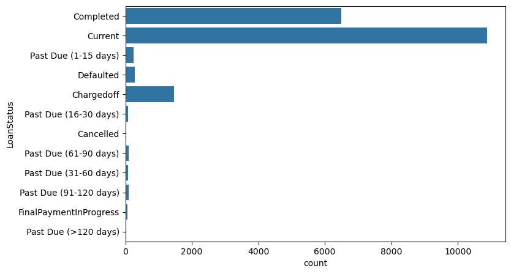

```python
#A bar plot is used to get a view of the distribution
plt.figure(figsize=[8,5])


default_color = sb.color_palette()[0]
sb.countplot(data= newloan_df, y ='LoanStatus', color = default_color );
```

According to the plot it appears that a large percentage of loans issued are current. This is closely followed by loans that have been completely paid off. A good number of borrowers have defaulted in their loans. On the extremely lower end are loans that have been cancelled and past due.

#### Distribution of Borrower APR.

This is the annual percentage rate charged to the borrower for a loan.

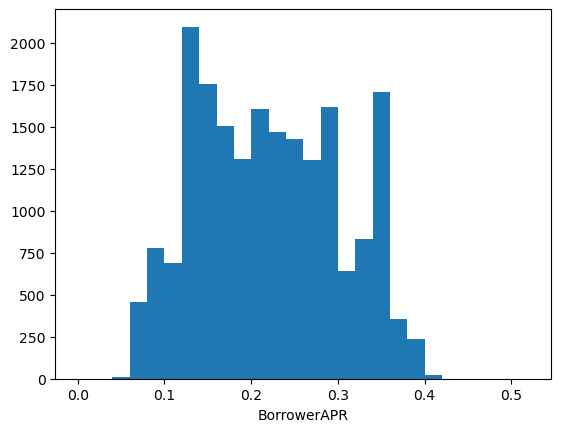

```python
# A histogram is used to describe the distribution of APR.
bins = np.arange(0,loan_df['BorrowerAPR'].max()+0.02,0.02 )

plt.hist(data = newloan_df, x='BorrowerAPR', bins =bins);
plt.xlabel('BorrowerAPR');
```

The distribution of borrower apr appears to be normaly distributed with a high concentration at a range of 0.1 to 0.35 where a spike occures.

#### What is the distribution of Borrower Rate?

This represents the borrower interest rates for the loan taken.

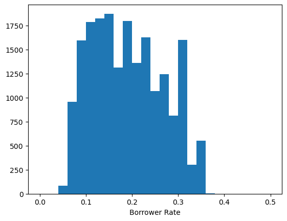

```python
# A histogram is plotted to visualize the distribution.
bins = np.arange(0,loan_df['BorrowerRate'].max()+0.02,0.02 )

plt.hist(data = newloan_df, x='BorrowerRate', bins = bins );
plt.xlabel('Borrower Rate');
```

The borrower rate distribution appears to be similar to the borrower apr distribution. Both have a normal distribution with a spike at the values close to 0.3. This means that the rates of APR and borrower interest rates on the loans borrowed are close in range.

#### What are the ranges for the estimated returns?

The estimated return is the difference between the Estimated Effective Yield and the Estimated Loss Rate.

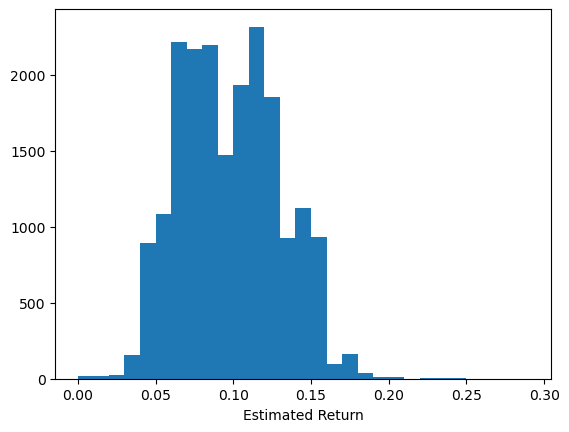

```python
# A histogram is plotted to visualize the distribution.
bins = np.arange(0,loan_df['EstimatedReturn'].max()+0.01,0.01 )

plt.hist(data = newloan_df, x='EstimatedReturn', bins = bins);
plt.xlabel('Estimated Return');
```

The estimated returns appear to be normally distributed with majority of the returns ranging between 0.05 to 0.15.

#### What are the on time prosper payments?

These variable represents the number of times a borrower has paid back their loans on time.

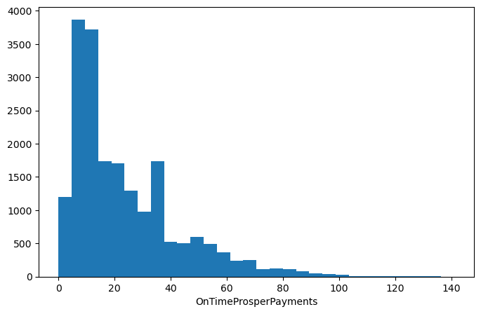

```python
# A histogram is used.
plt.figure(figsize=[8,5])

plt.hist(data = newloan_df, x='OnTimeProsperPayments', bins = 30);
plt.xlabel('OnTimeProsperPayments');
```

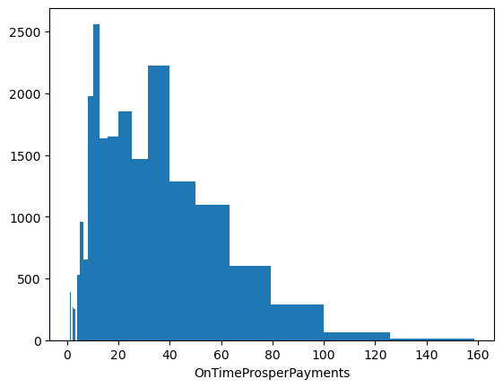

```python
# A log scale transformation is applied.
log_binsize = 0.1
bins = 10 ** np.arange(0, np.log10(loan_df['OnTimeProsperPayments'].max())+log_binsize, log_binsize)

plt.hist(data = newloan_df, x='OnTimeProsperPayments', bins = bins);
plt.xlabel('OnTimeProsperPayments');
```

The on time prosper payments is highly skewed to the right. A log tranformation is applied to get more insight on the distribution. The plot reveals that a majority of borrowers have made on time payments less than 40 times.

#### What is the average amount of loan most borrowed?

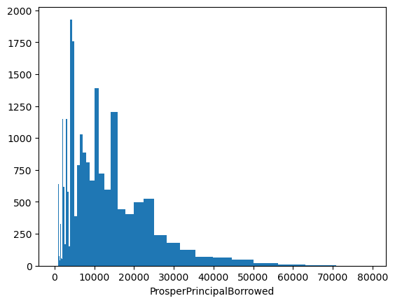

```python
## A log scale transformation is applied.
log_binsize = 0.05
bins = 10 ** np.arange(0, np.log10(loan_df['ProsperPrincipalBorrowed'].max())+log_binsize, log_binsize)

plt.hist(data = newloan_df, x='ProsperPrincipalBorrowed', bins=bins);
plt.xlabel('ProsperPrincipalBorrowed');
```

The data shows that the distribution is highly skewed to the right. A log scale is applied which reveals that the most common loan amounts borrowed are below 20,000. There are various peaks observed in the plot.

#### What is the employment status of most loan borrowers?

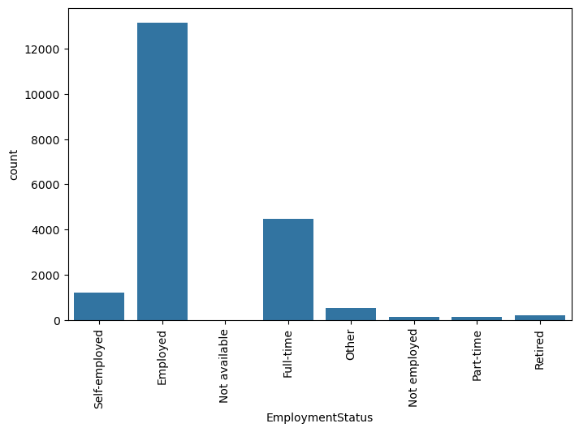

```python
# A bar plot is used to plot the status.
plt.figure(figsize=[8,5])

default_color = sb.color_palette()[0]
sb.countplot(data= newloan_df, x ='EmploymentStatus', color = default_color )
plt.xticks(rotation=90);
```

#### What is the income range distribution of the borrowers?

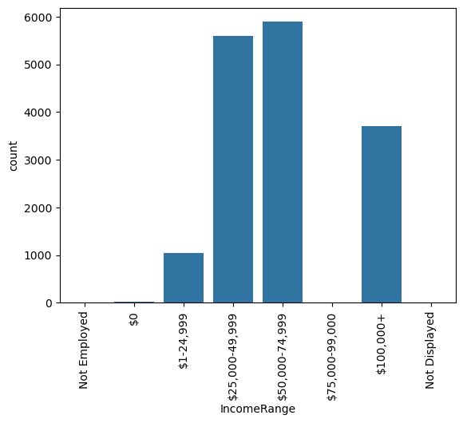

```python
# A bar plot is used to visualize the distribution.
base_color =sb.color_palette()[0]

sb.countplot(data = newloan_df, x='IncomeRange', color = base_color);
plt.xticks(rotation=90);
```

### Discuss the distribution(s) of your variable(s) of interest. Were there any unusual points? Did you need to perform any transformations?

The loan status was categorical with a high number indicating that the loans were current and very few were past due. The borrower rate, borrower APR and the estimated return variables were normally distriuted with a similar range. On the other hand the on time prosper payments and the prosper principal borrowed showed a skewed distribution and a log transformation was applied to get more insight to the distribution of the data. The employment status and the income range were also categorical in nature.

### Of the features you investigated, were there any unusual distributions? Did you perform any operations on the data to tidy, adjust, or change the form of the data? If so, why did you do this?

There were null values observed in some of the columns but they were indicative of no past record and so according to me they were not affecting the analysis in any negative way. To sample the data, the null rows were dropped off from the dataset from the selected variables.

## Bivariate Exploration

#### How does employment status affect the loan status?

```python
# Loan status and employment status are grouped together uing the groupby function.
LEstatus = newloan_df.groupby(['LoanStatus', 'EmploymentStatus']).size()
LEstatus = LEstatus.reset_index(name='count')
LEstatus = LEstatus.pivot(index = 'LoanStatus', columns = 'EmploymentStatus', values = 'count')
LEstatus.fillna(value = 0, inplace = True)
LEstatus
```

| EmploymentStatus LoanStatus | Self-employed | Employed | Not available | Full-time | Other | Not employed | Part-time | Retired |
| --- | --- | --- | --- | --- | --- | --- | --- | --- |
| Completed | 303 | 3196 | 0 | 2692 | 92 | 42 | 68 | 101 |
| Current | 700 | 8520 | 0 | 1162 | 357 | 47 | 22 | 72 |
| Past Due (1-15 days) | 13 | 197 | 0 | 23 | 11 | 1 | 2 | 2 |
| Defaulted | 13 | 146 | 0 | 113 | 9 | 2 | 2 | 6 |
| Chargedoff | 127 | 787 | 0 | 438 | 45 | 20 | 23 | 26 |
| Past Due (16-30 days) | 7 | 55 | 0 | 7 | 3 | 1 | 1 | 0 |
| Cancelled | 0 | 0 | 0 | 0 | 0 | 0 | 0 | 0 |
| Past Due (61-90 days) | 10 | 73 | 0 | 10 | 3 | 1 | 1 | 0 |
| Past Due (31-60 days) | 5 | 64 | 0 | 12 | 2 | 0 | 2 | 1 |
| Past Due (91-120 days) | 6 | 69 | 0 | 12 | 2 | 2 | 2 | 0 |
| FinalPaymentInProgress | 4 | 45 | 0 | 10 | 2 | 0 | 0 | 0 |
| Past Due (>120 days) | 0 | 5 | 0 | 0 | 0 | 0 | 0 | 0 |

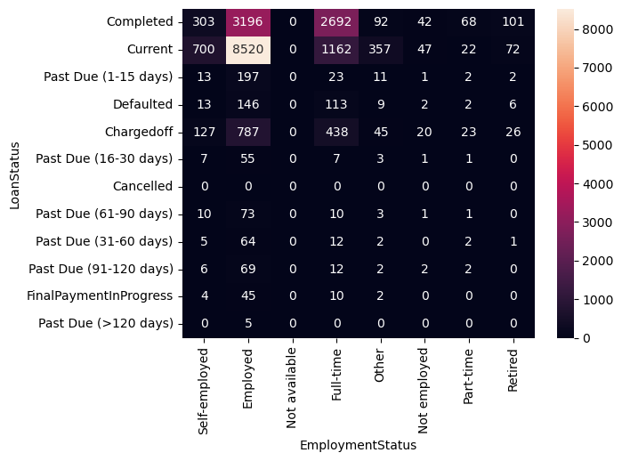

```python
# A heatmap is used to analyze the correlation.
sb.heatmap(LEstatus, annot = True, fmt= 'd');
```

#### How does the income range relate to on time prosper payments?

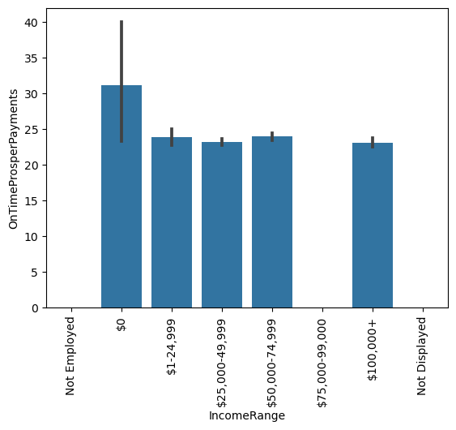

```python
# A bar plot is used.
base_color = sb.color_palette()[0]
sb.barplot(data = newloan_df, x = 'IncomeRange', y='OnTimeProsperPayments', color = base_color);
plt.xticks(rotation=90);
```

The income range of 0 dollars are the borrowers that have the highest number of on time loan payments which was very unusual.

#### How does the borrower rate relate to estimated return?

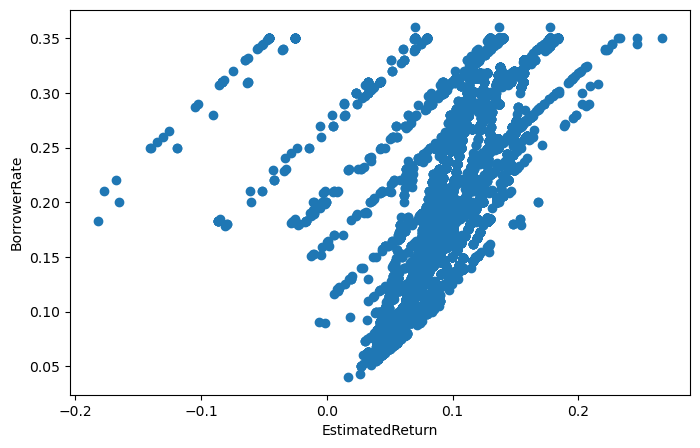

```python
#A scatter plot is utilized.
plt.figure(figsize=[8,5])

plt.scatter(data=newloan_df, y ='BorrowerRate', x = 'EstimatedReturn');
plt.xlabel('EstimatedReturn');
plt.ylabel('BorrowerRate');
```

There appears to be a positive correlation between the two variables. High estimated returns are associated with high borrower rates.

#### What are the interest rates for the loans borrowed?

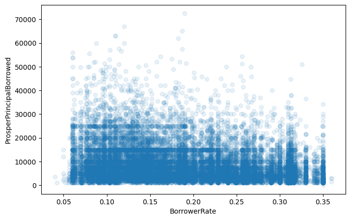

```python
# A scatter plot is used to visualize the relationship
plt.figure(figsize=[8,5])

plt.scatter(data=newloan_df, x='BorrowerRate', y= 'ProsperPrincipalBorrowed', alpha = 1/10);
plt.xlabel('BorrowerRate');
plt.ylabel('ProsperPrincipalBorrowed');
```

It appears that the borrower rate is not a huge factor affecting the amount of principal borrowed.

#### How does the employment status affect on time payments?

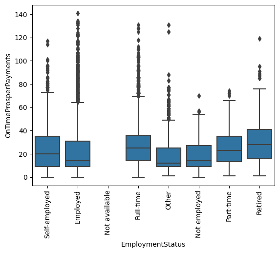

```python
# A box plot is used to visualize the relationship.
base_color = sb.color_palette()[0]
sb.boxplot(data = newloan_df, x='EmploymentStatus',y = 'OnTimeProsperPayments', color = base_color );
plt.xticks(rotation=90);
```

## Multivariate Exploration

#### How is the borrower rate and borrower apr affect the estimated return?

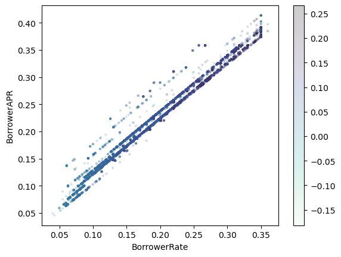

```python
# A scatter plot is used.
plt.scatter(data = newloan_df, x = 'BorrowerRate', y = 'BorrowerAPR', c = 'EstimatedReturn',
            cmap = 'mako_r', alpha = 0.2, marker='.',linewidth = 0)
plt.colorbar()
plt.xlabel('BorrowerRate');
plt.ylabel('BorrowerAPR');
```

The borrower rate and borrower apr all show a positive correlation to estimated returns. An increase in the two variables means an increase in the expected returns.

#### According to the amount of loans borrowed, what is the status of those and how many of the borrowers pay their loans on time?

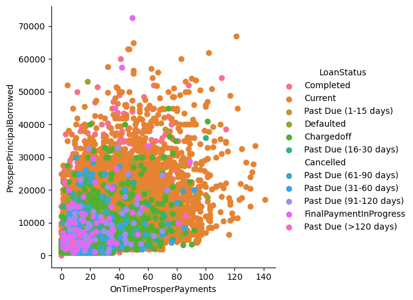

```python
# A scatter plot is used.
g = sb.FacetGrid(data = newloan_df, hue = 'LoanStatus', size = 5)
g.map(plt.scatter, 'OnTimeProsperPayments','ProsperPrincipalBorrowed')
g.add_legend()
```

Majority of the loan borrowers had not completed their loans and were still current. They were still the majority who paid their loans on time and the principal amounts they borrowed varied.It is notable that they borrowed high amounts of loans as compared to other statuses.

#### What is the borrower rate of the prosper principal borrowed and how does it affect the estimated return?

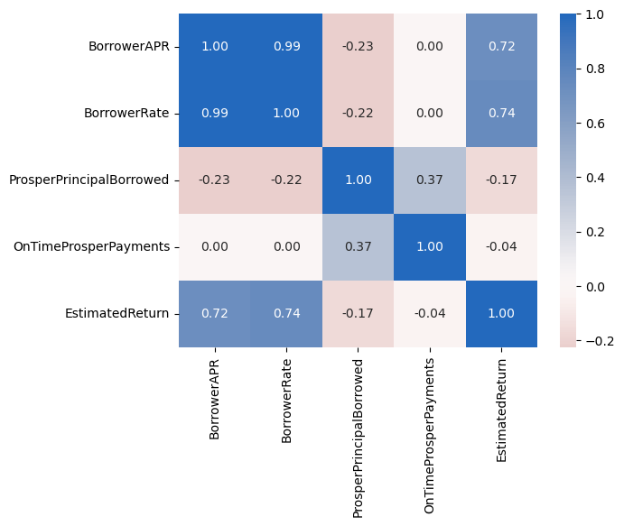

```python
#A heat map is used to show the correlation.
sb.heatmap(newloan_df.corr(), annot = True, fmt = '.2f', cmap = 'vlag_r', center = 0);
```

Borrower rates highly correlated with borrower APR and the estimated return but poorly correlated with prosper principal borrowed and in time prosper payments.

### Talk about some of the relationships you observed in this part of the investigation. Were there features that strengthened each other in terms of looking at your feature(s) of interest?

The borrower rate and borrower apr all show a positive correlation to estimated returns. An increase in the two variables means an increase in the expected returns. Majority of the loan borrowers had not completed their loans and were still current. They were still the majority who paid their loans on time and the principal amounts they borrowed varied.It is notable that they borrowed high amounts of loans as compared to other statuses.

### Were there any interesting or surprising interactions between features?

It was an interesting fact that the interest rates incurred by the borrower did not affect the principal amount borrowed.

## Conclusions

Different plots were used to visualize the variable, their distributions and their relationships. It can be noted that the employment status and income range were factors that were considered when issuing of loans and the borrower apr and rates heavily influenced the estimated returns.